# Predicting Exercise Class from Activity Measurement

TMA

Friday, August 22, 2014

========================================

## 1. Summary

The goal of this task was to predict the manner of exercise performed by participants in the Weight Lifting Exercises (WLE) Dataset http://groupware.les.inf.puc-rio.br/har. Predictive data consisted of different measurements obtained from four different wearable devices.

I compared two approaches for modeling predictions, both using the random forest method. In the first approach I trained a single random forest model on all the predictor variables in a single step.

In the second approach I took two steps. First I trained four independent random forests, one for each device, to identify each device’s most important variables. Then I built a random forest model using only those important variables.

Both approaches resulted in expected accuracy (based on their respective OOB accuracy) that rounds to 1.0. The expected out of sample error rates were 0.57% and 0.50%, respectively.

## 2. Data Processing

### The experiment

The WLE data describe an experiment in which six human participants performed exercises known as *dumbbell biceps curls*. The experimenters instructed the participants to perform the exercises either properly or improperly, as indicated by five different classes: Class A indicated proper form, while Classes B, C, D, and E indicated improper form, defined in different specific ways.

The experimenters measured participants’ activity from sensors in four different locations, including on three wearable devices. The locations were on the dumbbells themselves, on a belt worn around the waist, on an arm-band, and on a glove. Each device’s metrics included tri-axis measures from an accelerometer, a gyroscope, and a magnetometer.

To read more, visit the WLE website: http://groupware.les.inf.puc-rio.br/public/papers/2013.Velloso.QAR-WLE.pdf.

### The data

The data consists of a preprocessed training data set including 19,622 observations among 160 variables, and a testing data set including 20 observations. The testing data did not label the “classe” variable, the discovery of which was the purpose of this analysis.

#### Removing non-predictive variables

To eliminate variables not derived from wearable device measurements, I subset the training data to include only variables that reflected discrete measures (as opposed to statistical measures, such as variance or skew) from the wearable devices, leaving 52 possible predictor variables. These possible predictor variables comprised 13 variables for each of the four devices.

Then I split the training data 80/20, randomly sampling the outcome variable, “classe.”

Table 1 lists the predictor variables used in the first model.

##### Table 1: Predictive Variables

| Belt | Arm | Dumbbells | Forearm |
| --- | --- | --- | --- |
| roll_belt | roll_arm | roll_dumbbell | roll_forearm |
| pitch_belt | pitch_arm | pitch_dumbbell | pitch_forearm |
| yaw_belt | yaw_arm | yaw_dumbbell | yaw_forearm |
| total_accel_belt | total_accel_arm | total_accel_dumbbell | total_accel_forearm |
| gyros_belt_x | gyros_arm_x | gyros_dumbbell_x | gyros_forearm_x |
| gyros_belt_y | gyros_arm_y | gyros_dumbbell_y | gyros_forearm_y |
| gyros_belt_z | gyros_arm_z | gyros_dumbbell_z | gyros_forearm_z |
| accel_belt_x | accel_arm_x | accel_dumbbell_x | accel_forearm_x |
| accel_belt_y | accel_arm_y | accel_dumbbell_y | accel_forearm_y |
| accel_belt_z | accel_arm_z | accel_dumbbell_z | accel_forearm_z |
| magnet_belt_x | magnet_arm_x | magnet_dumbbell_x | magnet_forearm_x |
| magnet_belt_y | magnet_arm_y | magnet_dumbbell_y | magnet_forearm_y |
| magnet_belt_z | magnet_arm_z | magnet_dumbbell_z | magnet_forearm_z |

## 3. Modeling

### Model 1: *rfTrain*

I trained a random forest model on the 80% training subset, using the default parameters from the caret package.

### Model 2: *rfTrain2*

I trained four random forest models - *rfBelt*, *rfArm*, *rfDumbbells*, *rfForearm* - on the 80% training subset, using the default parameters from the caret package. According to their names, I confined each model to variables from its appropriate device location.

Using only the most important variables identified from each location - defining “important” as greater than 50 - I trained a random forest model on the same 80% training data subset, using the default parameters from the caret package.

## 4. Results

### Important variables

Among the four location-specific random forest models, the following variables met the threshold of variable importance greater than 50.

##### Table 2. Most important variables from each location

| All locations |
| --- |
| roll_belt |
| pitch_belt |
| yaw_belt |
| roll_arm |
| pitch_arm |
| gyros_arm_x |
| accel_arm_x |
| accel_arm_y |
| accel_arm_z |
| magnet_arm_y |
| magnet_dumbbell_y |
| magnet_dumbbell_z |
| roll_forearm |
| pitch_forearm |

### rfTrain results

*rfTrain* is the model generated in a single step, training a random forest model on the entire training data set among all 52 predictor variables. Its predicted error rate, estimated from the OOB error rate used to select the best tree, was 0.57%.

```
Call:
 randomForest(x = x, y = y, mtry = param$mtry, verbose = FALSE)
               Type of random forest: classification
                     Number of trees: 500
No. of variables tried at each split: 27

        OOB estimate of  error rate: 0.57%
Confusion matrix:
     A    B    C    D    E class.error
A 4500    4    1    0    2    0.001553
B   17 2986    8    1    0    0.008632
C    0   12 2739    8    0    0.007249
D    0    0   22 2514    3    0.009846
E    0    1    5    5 2869    0.003819
```

### rfTrain2 results

```
Call:
 randomForest(x = x, y = y, mtry = param$mtry, verbose = FALSE)
               Type of random forest: classification
                     Number of trees: 500
No. of variables tried at each split: 2

        OOB estimate of  error rate: 0.5%
Confusion matrix:
     A    B    C    D    E class.error
A 4501    4    1    0    1    0.001331
B    7 2991   12    1    1    0.006972
C    0   16 2740    3    0    0.006887
D    0    0   17 2520    2    0.007483
E    0    4    3    6 2867    0.004514
```

## 5. Most important locations: belt and dumbbells

### Figure 1. Most Important Variables, *rfTrain* and *rfTrain2*

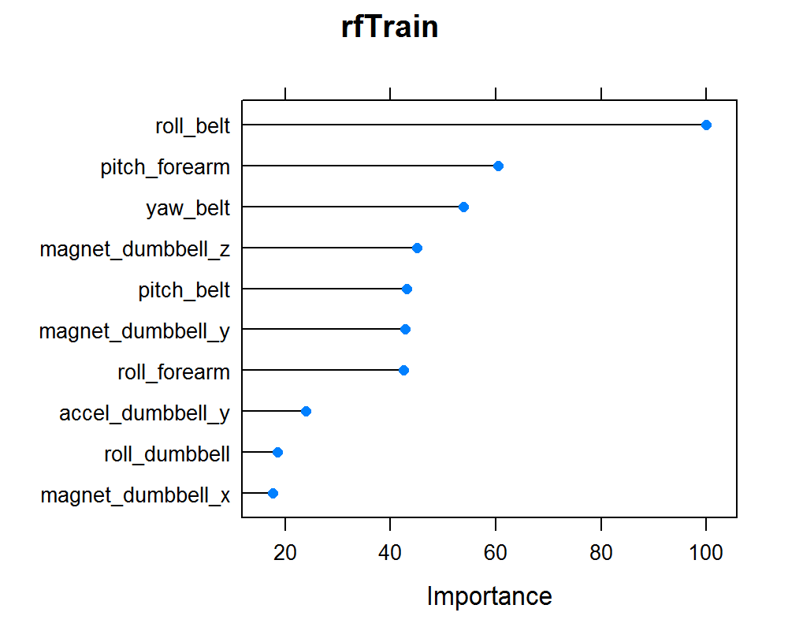

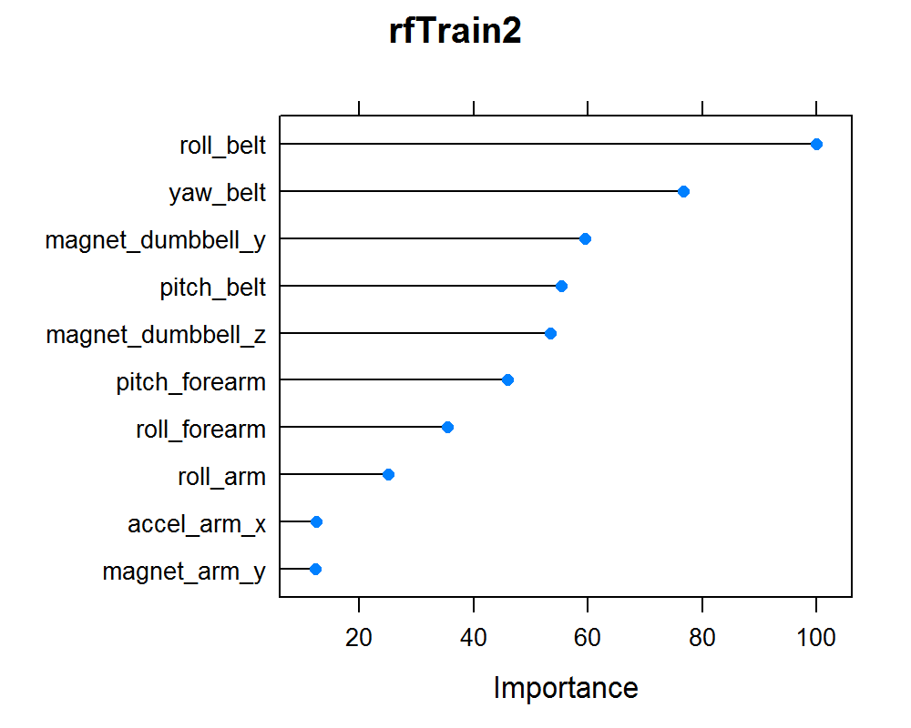

That the dumbbells themselves were an important measurement location for differentiating correct performance of biceps curls does not surprise me. What does surprise me is that the belt location was so important. It makes me wonder exactly how classes B, C, D, and E were performed such that belt measurements were helpful at distinguishing them.

## 6. Error prediction

The OOB error rate is an unbiased estimate of out of sample error rate, so there is no need for additional cross validation (see http://www.stat.berkeley.edu/~breiman/RandomForests/cc_home.htm#ooberr).

For any graders who insist on additional cross-validation, I also tested both models on the held-out training data.

```r
library(caret)


cMTrain <- confusionMatrix(predTrain, cvTrain$classe)
cMTrain
```

```
Confusion Matrix and Statistics

          Reference
Prediction    A    B    C    D    E
         A 1073   13    0    0    0
         B    0  770    3    0    0
         C    0    2  657    7    1
         D    0    0    3  670    1
         E    0    0    0    0  725

Overall Statistics

               Accuracy : 0.992
                 95% CI : (0.989, 0.995)
    No Information Rate : 0.273
    P-Value [Acc > NIR] : <2e-16

                  Kappa : 0.99
 Mcnemar's Test P-Value : NA

Statistics by Class:

                     Class: A Class: B Class: C Class: D Class: E
Sensitivity             1.000    0.981    0.991    0.990    0.997
Specificity             0.995    0.999    0.997    0.999    1.000
Pos Pred Value          0.988    0.996    0.985    0.994    1.000
Neg Pred Value          1.000    0.995    0.998    0.998    0.999
Prevalence              0.273    0.200    0.169    0.172    0.185
Detection Rate          0.273    0.196    0.167    0.171    0.185
Detection Prevalence    0.277    0.197    0.170    0.172    0.185
Balanced Accuracy       0.998    0.990    0.994    0.994    0.999
```

```r
cvError <- (1 - sum(diag(cMTrain$table))/sum(apply(cMTrain$table, 2, sum)))
cvError
```

```
[1] 0.007643
```

```r
cMTrain2 <- confusionMatrix(predTrain2, cvTrain$classe)
cMTrain2
```

```
Confusion Matrix and Statistics

          Reference
Prediction    A    B    C    D    E
         A 1073    3    0    0    0
         B    0  778    4    0    2
         C    0    4  658    6    1
         D    0    0    1  670    2
         E    0    0    0    1  722

Overall Statistics

               Accuracy : 0.994
                 95% CI : (0.991, 0.996)
    No Information Rate : 0.273
    P-Value [Acc > NIR] : <2e-16

                  Kappa : 0.992
 Mcnemar's Test P-Value : NA

Statistics by Class:

                     Class: A Class: B Class: C Class: D Class: E
Sensitivity             1.000    0.991    0.992    0.990    0.993
Specificity             0.999    0.998    0.997    0.999    1.000
Pos Pred Value          0.997    0.992    0.984    0.996    0.999
Neg Pred Value          1.000    0.998    0.998    0.998    0.998
Prevalence              0.273    0.200    0.169    0.172    0.185
Detection Rate          0.273    0.198    0.168    0.171    0.184
Detection Prevalence    0.274    0.200    0.170    0.171    0.184
Balanced Accuracy       0.999    0.995    0.995    0.994    0.996
```

```r
cv2Error <- (1 - sum(diag(cMTrain2$table))/sum(apply(cMTrain2$table, 2, sum)))
cv2Error
```

```
[1] 0.006115
```

The first model’s error prediction (based on the OOB error rate) is 0.0057. When tested on the cross-validation sample, the error rate was 0.0076.

The second model’s error prediction (based on the OOB error rate) is 0.0050. When tested on the cross-validation sample, the error rate was 0.0061.

For either model, the expected likelihood of predicting all 20 test cases correctly on the first attempt is approximately 0.995^20, or 0.90.